# State of the Ecosystem New England 2026

NEFMC CESC Update  
March 27, 2026

Joe Caracappa, lead editor, NEFSC

## State of the Ecosystem (SOE) reporting

### Improving ecosystem information and synthesis for fishery managers

- Ecosystem indicators linked to management objectives ([DePiper et al., 2017](https://academic.oup.com/icesjms/article/74/8/2076/3094701))
  - Contextual information
  - Report evolving since 2016
  - Fishery-relevant subset of full Ecosystem Status Reports
- Open science emphasis ([Bastille et al., 2020](https://doi.org/10.1080/08920753.2021.1846155))
- Used within Mid-Atlantic Fishery Management Council’s Ecosystem Process ([Muffley et al., 2020](https://doi.org/10.1080/08920753.2021.1846156))

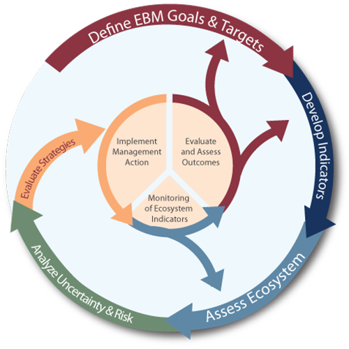

*The IEA Loop<sup>1</sup>*

[^1]: https://www.integratedecosystemassessment.noaa.gov/national/IEA-approach

## Ecosystem reporting at different levels of organization

**The SOE provides information at the ecosystem level**

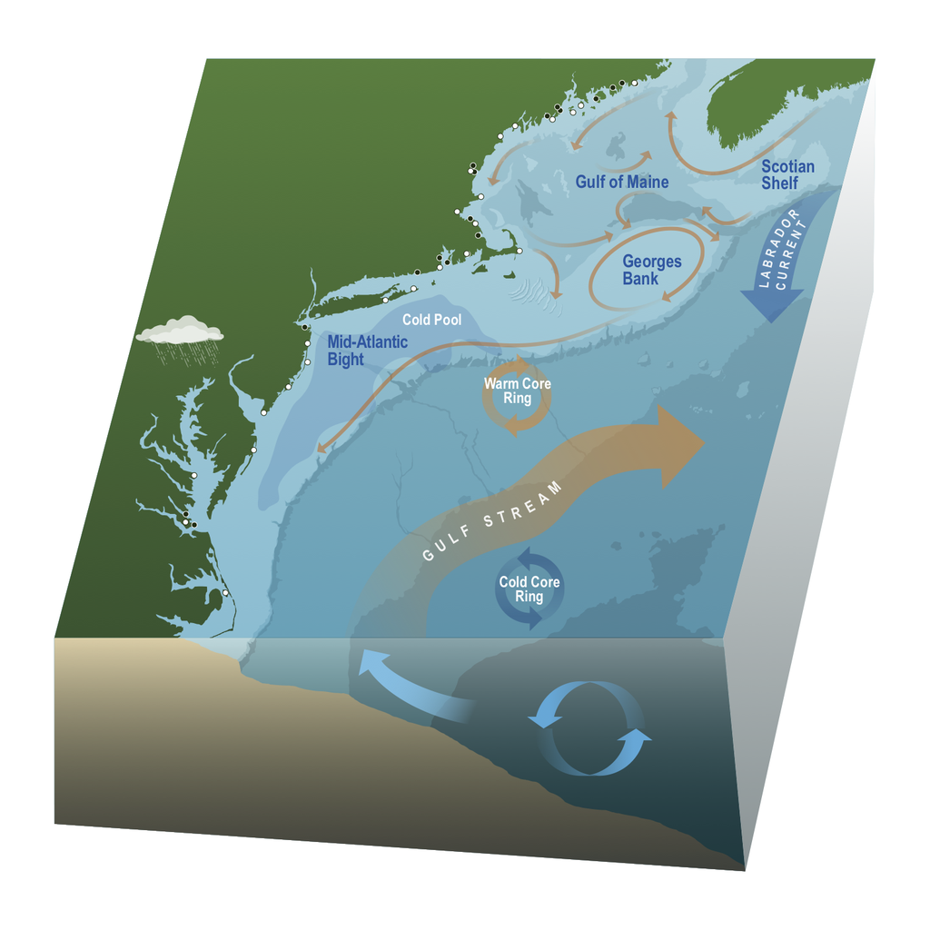

**Ecosystem and Socioeconomic Profiles (ESPs) provide information at the stock level**

Ecosystem and Socioeconomic Profiles support fisheries science and management by providing additional context that can help inform the development of the stock assessment model, as well as by communicating contextual information to fisheries managers.

[figure not shown]

[figure not shown]

## 2026 Report Structure

1. Graphical summary
   - Page 1 report card re: performance metrics
   - Page 2 risk summary bullets
   - Page 3 2025 snapshot
2. Performance relative to management objectives
   - *What* does the indicator say–up, down, stable?
   - *Why* do we think it is changing: explore drivers
3. Risks to meeting management objectives
   - Same *What* and *Why* as Performance Section
4. 2025 Highlights

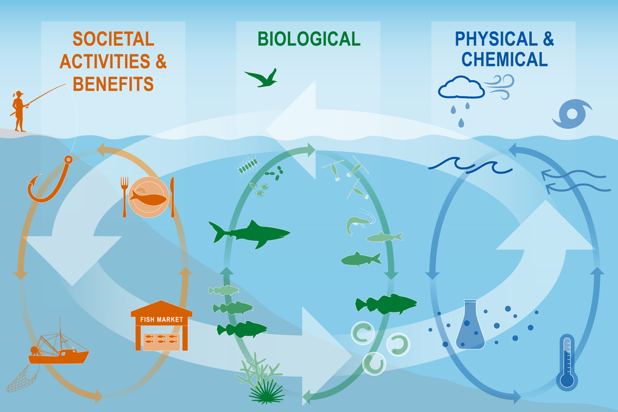

## Metrics, risks, drivers, and indicators

| Objective Categories | Indicators reported |
| --- | --- |
| Performance Metrics |  |
| Seafood Production | Landings; commercial total and by feeding guild; recreational harvest |
| Profits | Revenue decomposed to price and volume, profitability |
| Recreation | Angler trips; recreational fleet diversity; recreational catch diversity |
| Stability | Fishery and ecosystem volatility, adaptive capacity, and shifts from baseline |
| Social & Cultural | Community commercial fishing activity and risk factors |
| Protected Species | Bycatch; population (adult and juvenile) numbers, mortalities |
| Drivers of Performance |  |
| Management | Stock status; catch compared with catch limits |
| Biomass | Biomass or abundance by feeding guild from surveys |
| Environment | Climate and ecosystem risk indicators listed below |
| Risks to Meeting Objectives |  |
| Risks to Managing Spatially | Fish and cetacean distribution shifts |
| Risks to Managing Seasonally | Spawning and migration timing |
| Risks to Setting Catch Limits | Fish condition and recruitment |
| Other Ocean Uses | Fishery revenue and landings from wind lease areas by species and port |
| Drivers of Risks |  |
| Habitat and prey quality | Benthic and pelagic forage distribution; ocean temperature; changes in currents and Cold Pool |
| Phenology | Habitat timing: length of ocean summer, cold pool seasonal persistence |
| Drivers of productivity | Benthic and pelagic forage quality and abundance; ocean temperature and acidification |
| Other Ocean Uses | Wind development map; protected species presence and hotspots |

## State of the Ecosystem report scale and figures

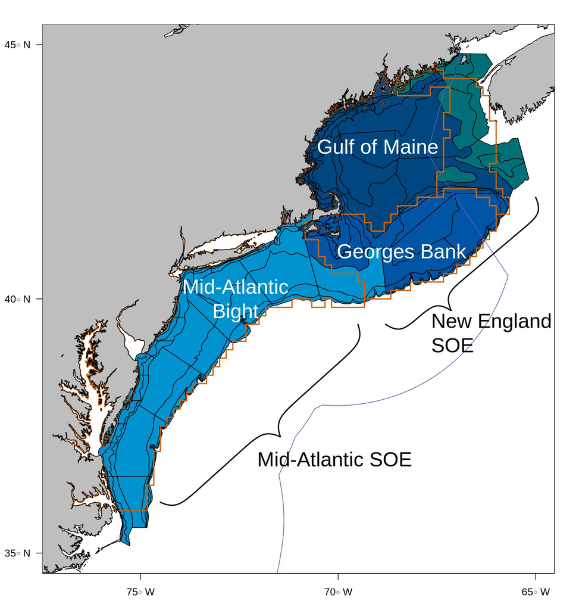

A [glossary of terms](https://noaa-edab.github.io/tech-doc/glossary.html) (2021 Memo 5), detailed [technical methods documentation](https://NOAA-EDAB.github.io/tech-doc) and [indicator data](https://github.com/NOAA-EDAB/ecodata) are available online.

Key to figures

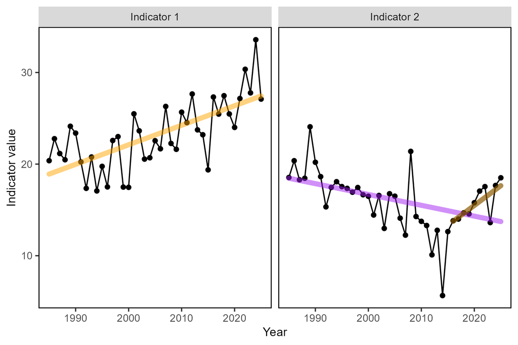

Long-term trends assessed only for 30+ years: [more information](https://noaa-edab.github.io/tech-doc/trend-analysis.html)

Short-term trends assessed for last 10 years of data OR a full time series <30 years

Orange line = significant increase

Purple line = significant decrease

No color line = not significant or < 30 years

Grey background = last 10 years

## Georges Bank: Summary of Performance relative to management objectives

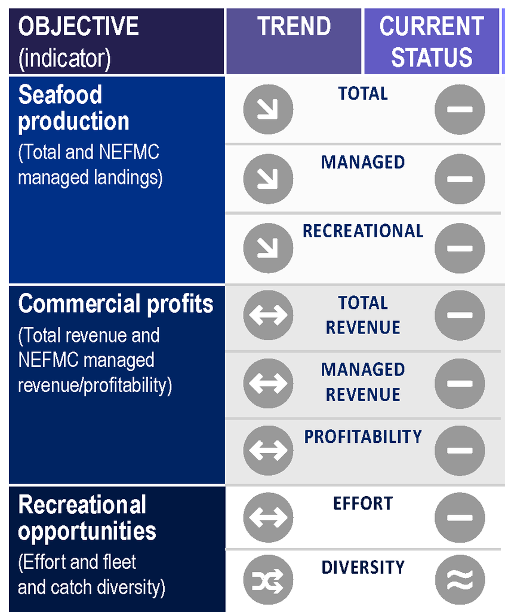

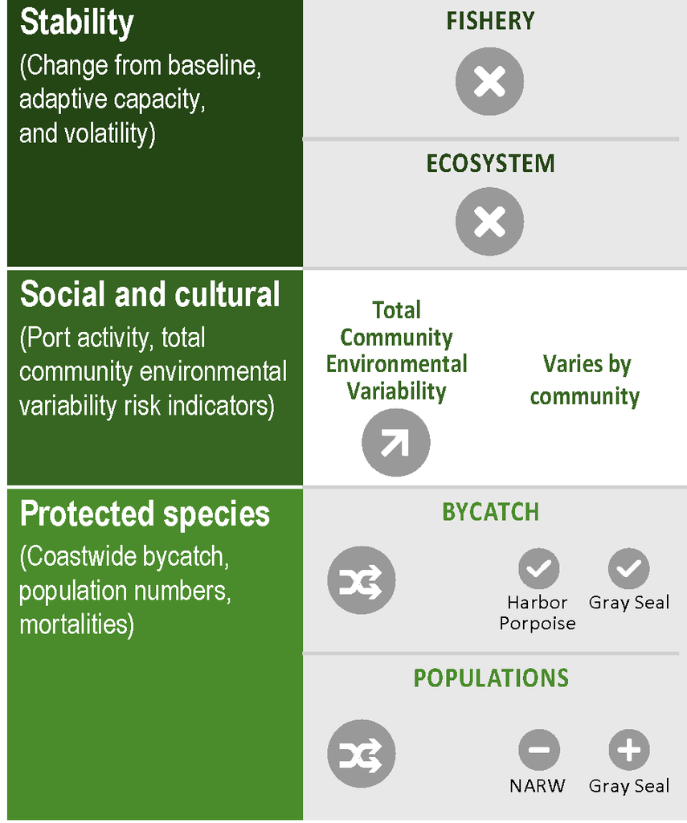

## Gulf of Maine: Summary of Performance relative to management objectives

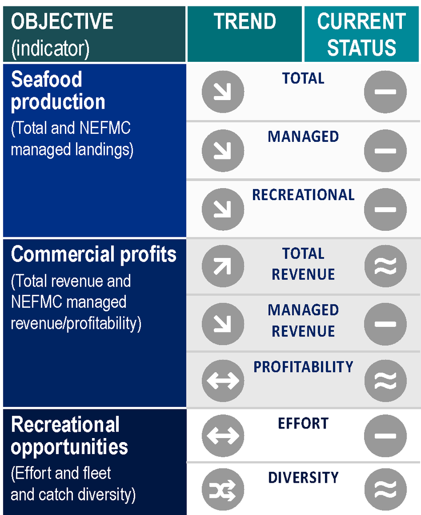

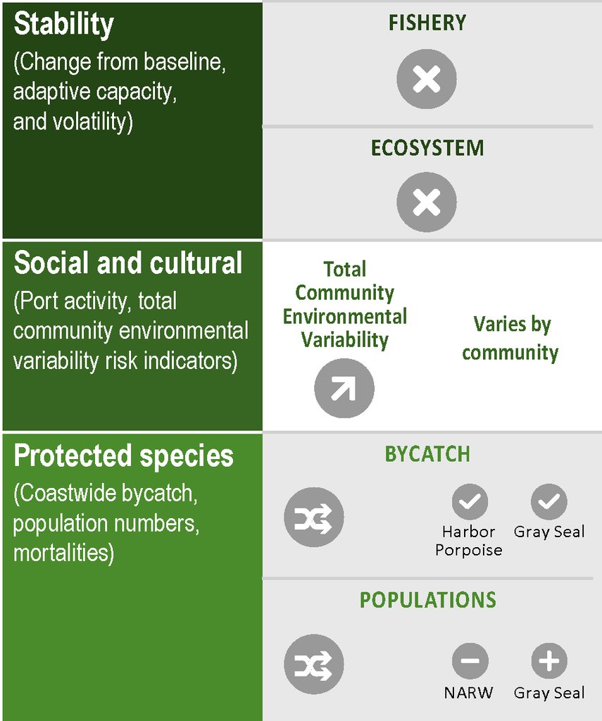

## Summary of Risks to meeting fishery management objectives

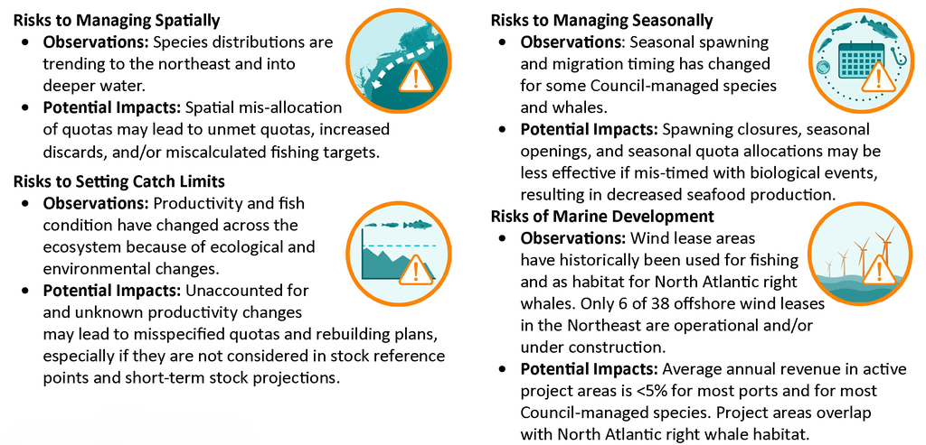

## New this year: Ocean Forecasts

[figure not shown]

## 2025 Highlights

### Fishing observations

- Reports of record levels of white marlin, and higher abundance of billfish, sandlance, Illex squid and Atlantic mackerel than in recent years.
- Observations of some species (Atlantic mackerel, striped bass, red drum, bluefish, and other gamefish) showed shifting distributions and unpredictable timing.
- Good hook and line fishing near the wind turbines.

We welcome your observations! northeast.ecosystem.highlights@noaa.gov

[figure not shown]

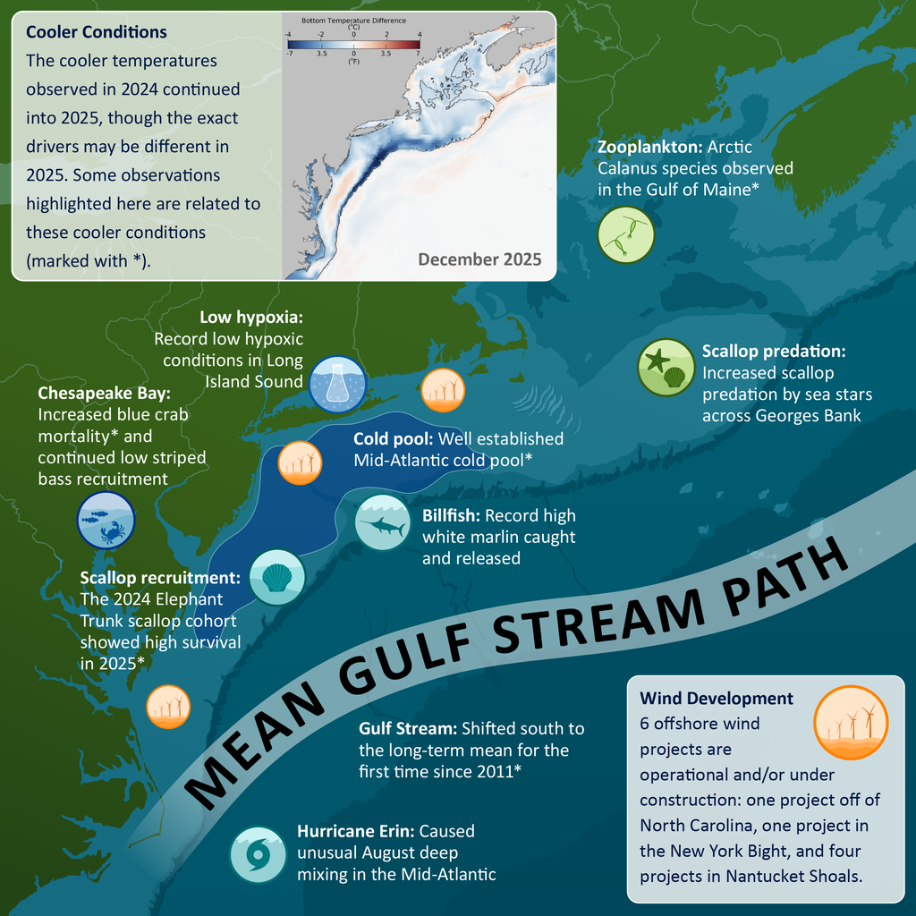

## Request tracking memo: Completed requests

| Request | Year | Priority |
| --- | --- | --- |
| SOE admin |  |  |
| Include estimates of inclusion years in request memo | 2022 | Lowest |
| System level thresholds/ ref pts |  |  |
| Trend Analysis | 2019 - 2024 | Highest |
| Multiple system drivers |  |  |
| Profits vs Revenue: net revenue indicator incomplete and different trend from gross | 2023-2024 | Highest |
| Clarify objectives, terminology and presentation for fishing community engagement/reliance/social indicators | 2022, 2024 | Highest |
| Time series of social indicators | 2023-2024 | Highest |
| Consider appropriate scale for social and economic indicators | 2024 | Highest |
| Add social and economic considerations in the Climate and Ecosystem risks section | 2024 | Highest |
| Clarify community definitions and consider indicators beyond landings to employment, subsistence | 2024 | Highest |
| Include community affordability in port level vulnerability | 2024 | High |
| Report changes in small fish and large fish biomass along with production anomalies | 2024 | Moderate |
| Relate OA to nutrient input; are there "dead zones" (hypoxia)? | 2021 | Low |
| Estuarine Water Quality | 2020 | Low |
| What determines a "risk"? Include aquaculture as a risk? | 2022 | Unranked |

## Request tracking memo: Highest priority requests

| Request | Year | Status | Priority |
| --- | --- | --- | --- |
| Short term forecasts |  |  |  |
| Short term forecasting from CEFI (water temp, productivity); Characterize current conditions in context of expected short term change | 2022, 2024, 2025 | In progress | Highest |
| Stock level indicators |  |  |  |
| Include cross references to stock specific products (ECSA/ESP), ensure consistent approaches; Establish more links between events and consequences (e.g. temp ranges for more species) | 2024 | In progress | Highest |
| SOE admin |  |  |  |
| Present relevant MA information in NE report | 2025 | In progress | Highest |
| Improve context and definitions of Management Objectives | 2025 | Not started | Highest |
| System level thresholds/ ref pts |  |  |  |
| Ecosystem Overfishing Indicators: compare to empirical thresholds; assess informativeness of indicators using simulation analysis; assess impact of phytoplankton size composition on EOF thresholds; de… | 2021-2024 | In progress | Highest |
| Develop regime shift analysis methods (e.g., inflection point analysis, influence statistics, break point analysis, early warning variance) | 2019-2025 | Not started | Highest |
| Conduct regime shift analysis of relevant indicators (e.g., zooplankton, forage fish, socioeconomic, etc). Use influence statistics to identify whether we are approaching tipping points. | 2019-2025 | Not started | Highest |
| Use community and port level information to inform fleet stability indicator | 2025 | In progress | Highest |
| Update CVA and explore trend changes when a new CVA is applied | 2025 | In progress | Highest |
| Include standardized language about uncertainty from e.g. IPCC or NCA applicable to each indicator or data input | 2024 | Not started | Highest |

## Highlights Methods

Observations solicited from:

- SOE contributors
- NEFSC colleagues
- Academic colleagues
- Management partners
- Fishing industry

Observations included if:

- Record high or low observations
- Different from recent conditions
- Reported by multiple sources
- Affecting fishery operations
- Newsworthy

*Not exhaustive list; Full impacts remain to be seen*

Please send observations to: northeast.ecosystem.highlights@noaa.gov

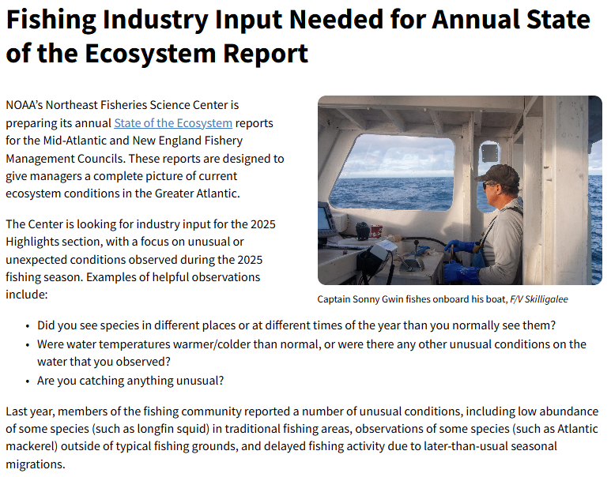

[See the call here](https://www.mafmc.org/newsfeed/2025/fishing-industry-input-needed-for-annual-state-of-the-ecosystem-report)

## Highlights: Cooler Northeast Shelf

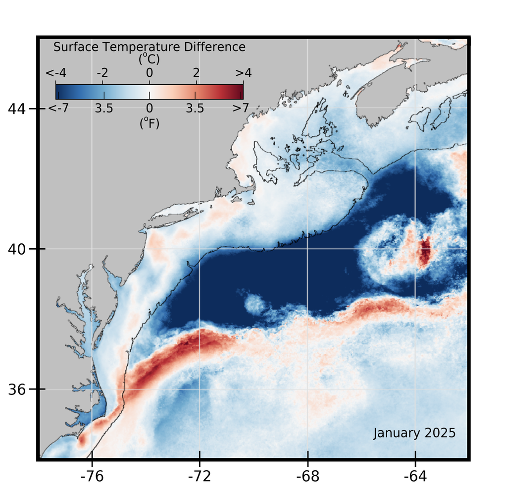

Globally, 2025 was the third warmest year on record

BUT, nearly all NE shelf seasonal surface and bottom temperatures were similar to or cooler than the longer term average

The Cold Pool was well-developed and more similar to the long-term average in terms of extent and persistence

In 2024, relative contributions of Labrador Slope Water and Warm Slope Water more similar to the long-term averages

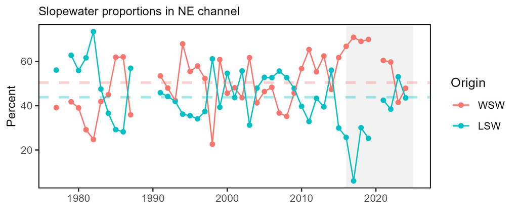

## Highlights: Notable observations

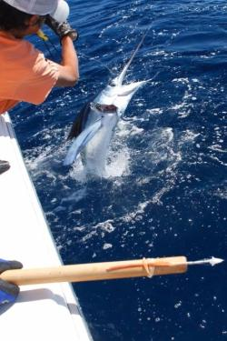

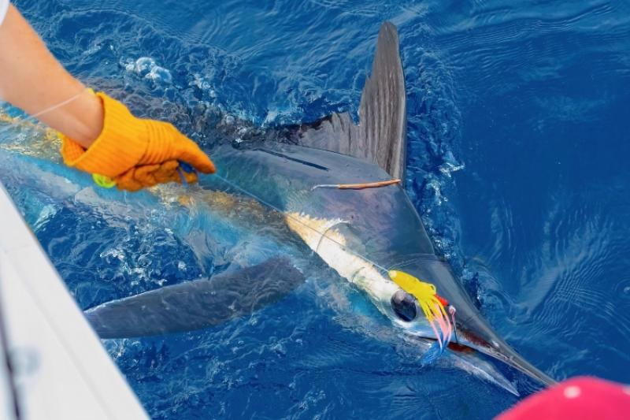

Images from [this NOAA webstory](https://www.fisheries.noaa.gov/feature-story/celebrating-our-top-taggers-citizen-science-month)

Observations on timing, location, and abundance:

- Fishers reported delayed migration of black sea bass and the absence of bluefish off of Rhode Island
- Good year for billfish, with >23,000 white marlin caught and released
- Fishers reported low catch and cold stunned red drum and spotted sea trout
- Fishers reported higher abundance and wider distributions of Atlantic mackerel, Illex squid, and sandlance
- Good scallop survival in the Elephant Trunk region according to the scallop survey
- Arctic copepods in GOM observed in the EcoMon survey

## CESC Discussion Questions

1. Which MOM6 forecast products are useful for the NEFMC? What is the appropriate scope and scale for decisions?
2. When considering probabilistic forecasts, what are the “events” we’re interested in predicting?
3. How do the SOE’s “management objectives” actually align with the NEFMC’s strategic planning? Should we redefine objectives?
4. How does the CESC recommend the SOE incorporate public/industry observations if no formal data is available?

Sydney Alhale (SEFSC)  
Andrew Applegate (NEFMC)  
Christina Asante  
Heather Baertlein (NMFS Atlantic HMS Management Division)  
Kimberly Bastille  
Aaron Beaver (Anchor QEA)  
Andy Beet  
Brandon Beltz  
Kristan Blackhart  
Ruth Boettcher (Virginia Department of Game and Inland Fisheries)  
Mandy Bromilow (NOAA Chesapeake Bay Office)  
Joseph Caracappa  
Samuel Chavez-Rosales  
Baoshan Chen (Stony Brook University)  
Zhuomin Chen (UConn)  
Doug Christel (GARFO)  
Patricia Clay  
Lisa Colburn  
Jennifer Cudney (NMFS Atlantic HMS Management Division)  
Tobey Curtis (NMFS Atlantic HMS Management Division)  
Kiley Dancy (MAFMC)  
Cameron Day  
Art Degaetano (Cornell U)  
Geret DePiper (TAMUCC)  
Bart DiFiore (MA DMF)  
Gregory Ellis  
Emily Farr (NMFS Office of Habitat Conservation)  
Michael Fogarty  
Paula Fratantoni  
Kevin Friedland

Marjy Friedrichs (VIMS)  
Sarah Gaichas (Hydra Scientific)  
Ben Galuardi (GARFO)  
Avijit Gangopadhyay (University of Massachusetts Dartmouth)  
James Gartland (VIMS)  
Lori Garzio (Rutgers University)  
Glen Gawarkiewicz (WHOI)  
Maxwell Grezlik  
Laura Gruenburg (Stony Brook University)  
Sean Hardison (UA Fairbanks)  
Amanda Hart  
Dvora Hart  
James Hawkes  
Cameron Hodgdon  
Christopher Hunt (University of New Hampshire)  
Cliff Hutt (NMFS Atlantic HMS Management Division)  
Kimberly Hyde  
Grace Jensen (WHOI)  
Toni Kerns (ASMFC)  
John Kocik  
Steve Kress (National Audubon Society’s Seabird Restoration Program)  
Young-Oh Kwon (Woods Hole Oceanographic Institution)  
Scott Large  
Gabe Larouche (Cornell U)  
Daniel Linden  
Robyn Linner (Maine Department of Marine Resources)  
Andrew Lipsky  
Sean Lucey (@ Orchard)  
Don Lyons (National Audubon Society’s Seabird Restoration Program)

Kevin Madley  
George Maynard  
Chris Melrose  
Anna Mercer  
Shannon Meseck  
Kiera Morrill  
Ryan Morse  
Ray Mroch (SEFSC)  
Nicole Mucci  
Brandon Muffley (MAFMC)  
Robert Murphy  
Kimberly Murray  
David Moe Nelson (NCCOS)  
Chris Orphanides  
Stephanie Owen  
Richard Pace  
Debi Palka  
Tom Parham (Maryland DNR)  
Chris Patrick (VIMS)  
CJ Pellerin (NOAA Chesapeake Bay Office)  
Charles Perretti  
Kristin Precoda  
Julie Reichert-Nguyen (NOAA Chesapeake Bay Office)  
Grace Roskar (NMFS Office of Habitat Conservation)  
Andrew Ross (GFDL)  
Jeffrey Runge (U Maine)  
Grace Saba (Rutgers University)  
Vincent Saba  
Sarah Salois

Chris Schillaci (GARFO)  
Amy Schueller (SEFSC)  
Teresa Schwemmer (URI)  
Tarsila Seara  
Dave Secor (CBL)  
Angela Silva  
Adrienne Silver (WHOI)  
Emily Slesinger  
Laurel Smith  
Linus Stoltz (Commercial Fisheries Research Foundation)  
Talya tenBrink (GARFO)  
Cameron Thompson (NERACOOS)  
Abigail Tyrell  
Rebecca Van Hoeck  
Ron Vogel (University of Maryland/NESDIS Center for Satellite Applications and Research)  
Bruce Vogt (NOAA Chesapeake Bay Office)  
John Walden  
Harvey Walsh  
Joseph Warren  
Sarah Weisberg (ICES)  
Changhua Weng  
Timothy White (Environmental Studies Program, BOEM)  
Dave Wilcox (VIMS)  
Sarah Wilkin (NMFS Office of Protected Resources)  
Mark Wuenschel  
Zhitao Yu  
Qian Zhang (U Maryland)  
NEFSC staff

[figure not shown]

## References

Bastille, K. et al. (2020). “Improving the IEA Approach Using Principles of Open Data Science”. In: *Coastal Management* 0.0. Publisher: Taylor & Francis _eprint: https://doi.org/10.1080/08920753.2021.1846155, pp. 1-18. ISSN: 0892-0753. DOI: [10.1080/08920753.2021.1846155](https://doi.org/10.1080%2F08920753.2021.1846155). URL: https://doi.org/10.1080/08920753.2021.1846155 (visited on Dec. 09, 2020).

DePiper, G. S. et al. (2017). “Operationalizing integrated ecosystem assessments within a multidisciplinary team: lessons learned from a worked example”. En. In: *ICES Journal of Marine Science* 74.8, pp. 2076-2086. ISSN: 1054-3139. DOI: [10.1093/icesjms/fsx038](https://doi.org/10.1093%2Ficesjms%2Ffsx038). URL: https://academic.oup.com/icesjms/article/74/8/2076/3094701 (visited on Mar. 09, 2018).

Muffley, B. et al. (2020). “There Is no I in EAFM Adapting Integrated Ecosystem Assessment for Mid-Atlantic Fisheries Management”. In: *Coastal Management* 0.0. Publisher: Taylor & Francis _eprint: https://doi.org/10.1080/08920753.2021.1846156, pp. 1-17. ISSN: 0892-0753. DOI: [10.1080/08920753.2021.1846156](https://doi.org/10.1080%2F08920753.2021.1846156). URL: https://doi.org/10.1080/08920753.2021.1846156 (visited on Dec. 09, 2020).

### Additional resources

- [ecodata R package](https://github.com/noaa-edab/ecodata)
- [Indicator catalog](https://noaa-edab.github.io/catalog/)
- [SOE Technical Documentation](https://noaa-edab.github.io/tech-doc)
- [SOE Reports on the web](https://www.fisheries.noaa.gov/new-england-mid-atlantic/ecosystems/state-ecosystem-reports-northeast-us-shelf)
- Slides available at https://nefsc.github.io/READ-EDAB-SOE_reports/
- Contact: joseph.caracappa@noaa.gov